# Risk Factor Analysis

## Outcome Variable

**Outcome Variable:** dead624

## Predictor Variables

**Intervention Variable:** ever_stunted024

**Adjustment Set:**

- sex
- arm
- brthmon
- vagbrth
- hhwealth_quart
- W_mage
- W_mhtcm
- W_mwtkg
- W_mbmi
- W_meducyrs
- W_feducyrs
- W_nrooms
- W_parity
- impsan
- safeh20
- delta_vagbrth
- delta_hhwealth_quart
- delta_W_mage
- delta_W_mhtcm
- delta_W_mwtkg
- delta_W_mbmi
- delta_W_meducyrs
- delta_W_feducyrs
- delta_W_nrooms
- delta_W_parity
- delta_impsan
- delta_safeh20

## Stratifying Variables

The analysis was stratified on these variable(s):

- studyid
- country

## Data Summary

| studyid | country | ever_stunted024 | dead624 | n_cell | n | outcome_variable |
| --- | --- | --- | --- | --- | --- | --- |
| ki0047075b-MAL-ED | BANGLADESH | 0 | 0 | 91 | 240 | dead624 |
| ki0047075b-MAL-ED | BANGLADESH | 0 | 1 | 0 | 240 | dead624 |
| ki0047075b-MAL-ED | BANGLADESH | 1 | 0 | 149 | 240 | dead624 |
| ki0047075b-MAL-ED | BANGLADESH | 1 | 1 | 0 | 240 | dead624 |
| ki0047075b-MAL-ED | INDIA | 0 | 0 | 89 | 235 | dead624 |
| ki0047075b-MAL-ED | INDIA | 0 | 1 | 0 | 235 | dead624 |
| ki0047075b-MAL-ED | INDIA | 1 | 0 | 146 | 235 | dead624 |
| ki0047075b-MAL-ED | INDIA | 1 | 1 | 0 | 235 | dead624 |
| ki0047075b-MAL-ED | PERU | 0 | 0 | 92 | 273 | dead624 |
| ki0047075b-MAL-ED | PERU | 0 | 1 | 0 | 273 | dead624 |
| ki0047075b-MAL-ED | PERU | 1 | 0 | 180 | 273 | dead624 |
| ki0047075b-MAL-ED | PERU | 1 | 1 | 1 | 273 | dead624 |
| ki0047075b-MAL-ED | SOUTH AFRICA | 0 | 0 | 99 | 261 | dead624 |
| ki0047075b-MAL-ED | SOUTH AFRICA | 0 | 1 | 0 | 261 | dead624 |
| ki0047075b-MAL-ED | SOUTH AFRICA | 1 | 0 | 162 | 261 | dead624 |
| ki0047075b-MAL-ED | SOUTH AFRICA | 1 | 1 | 0 | 261 | dead624 |
| ki0047075b-MAL-ED | TANZANIA, UNITED REPUBLIC OF | 0 | 0 | 31 | 245 | dead624 |
| ki0047075b-MAL-ED | TANZANIA, UNITED REPUBLIC OF | 0 | 1 | 0 | 245 | dead624 |
| ki0047075b-MAL-ED | TANZANIA, UNITED REPUBLIC OF | 1 | 0 | 214 | 245 | dead624 |
| ki0047075b-MAL-ED | TANZANIA, UNITED REPUBLIC OF | 1 | 1 | 0 | 245 | dead624 |
| ki1000109-EE | PAKISTAN | 0 | 0 | 39 | 374 | dead624 |
| ki1000109-EE | PAKISTAN | 0 | 1 | 0 | 374 | dead624 |
| ki1000109-EE | PAKISTAN | 1 | 0 | 331 | 374 | dead624 |
| ki1000109-EE | PAKISTAN | 1 | 1 | 4 | 374 | dead624 |
| ki1000304-VITAMIN-A | INDIA | 0 | 0 | 1494 | 3614 | dead624 |
| ki1000304-VITAMIN-A | INDIA | 0 | 1 | 9 | 3614 | dead624 |
| ki1000304-VITAMIN-A | INDIA | 1 | 0 | 2089 | 3614 | dead624 |
| ki1000304-VITAMIN-A | INDIA | 1 | 1 | 22 | 3614 | dead624 |
| ki1000304b-SAS-CompFeed | INDIA | 0 | 0 | 404 | 1389 | dead624 |
| ki1000304b-SAS-CompFeed | INDIA | 0 | 1 | 0 | 1389 | dead624 |
| ki1000304b-SAS-CompFeed | INDIA | 1 | 0 | 973 | 1389 | dead624 |
| ki1000304b-SAS-CompFeed | INDIA | 1 | 1 | 12 | 1389 | dead624 |
| ki1000304b-SAS-FoodSuppl | INDIA | 0 | 0 | 59 | 402 | dead624 |
| ki1000304b-SAS-FoodSuppl | INDIA | 0 | 1 | 0 | 402 | dead624 |
| ki1000304b-SAS-FoodSuppl | INDIA | 1 | 0 | 339 | 402 | dead624 |
| ki1000304b-SAS-FoodSuppl | INDIA | 1 | 1 | 4 | 402 | dead624 |
| ki1017093b-PROVIDE | BANGLADESH | 0 | 0 | 319 | 617 | dead624 |
| ki1017093b-PROVIDE | BANGLADESH | 0 | 1 | 2 | 617 | dead624 |
| ki1017093b-PROVIDE | BANGLADESH | 1 | 0 | 296 | 617 | dead624 |
| ki1017093b-PROVIDE | BANGLADESH | 1 | 1 | 0 | 617 | dead624 |
| ki1066203-TanzaniaChild2 | TANZANIA, UNITED REPUBLIC OF | 0 | 0 | 1312 | 2096 | dead624 |
| ki1066203-TanzaniaChild2 | TANZANIA, UNITED REPUBLIC OF | 0 | 1 | 0 | 2096 | dead624 |
| ki1066203-TanzaniaChild2 | TANZANIA, UNITED REPUBLIC OF | 1 | 0 | 784 | 2096 | dead624 |
| ki1066203-TanzaniaChild2 | TANZANIA, UNITED REPUBLIC OF | 1 | 1 | 0 | 2096 | dead624 |
| ki1101329-Keneba | GAMBIA | 0 | 0 | 1281 | 2748 | dead624 |
| ki1101329-Keneba | GAMBIA | 0 | 1 | 16 | 2748 | dead624 |
| ki1101329-Keneba | GAMBIA | 1 | 0 | 1423 | 2748 | dead624 |
| ki1101329-Keneba | GAMBIA | 1 | 1 | 28 | 2748 | dead624 |
| ki1112895-Burkina Faso Zn | BURKINA FASO | 0 | 0 | 4566 | 7162 | dead624 |
| ki1112895-Burkina Faso Zn | BURKINA FASO | 0 | 1 | 22 | 7162 | dead624 |
| ki1112895-Burkina Faso Zn | BURKINA FASO | 1 | 0 | 2557 | 7162 | dead624 |
| ki1112895-Burkina Faso Zn | BURKINA FASO | 1 | 1 | 17 | 7162 | dead624 |
| ki1113344-GMS-Nepal | NEPAL | 0 | 0 | 174 | 592 | dead624 |
| ki1113344-GMS-Nepal | NEPAL | 0 | 1 | 1 | 592 | dead624 |
| ki1113344-GMS-Nepal | NEPAL | 1 | 0 | 416 | 592 | dead624 |
| ki1113344-GMS-Nepal | NEPAL | 1 | 1 | 1 | 592 | dead624 |
| ki1126311-ZVITAMBO | ZIMBABWE | 0 | 0 | 6242 | 11708 | dead624 |
| ki1126311-ZVITAMBO | ZIMBABWE | 0 | 1 | 128 | 11708 | dead624 |
| ki1126311-ZVITAMBO | ZIMBABWE | 1 | 0 | 5060 | 11708 | dead624 |
| ki1126311-ZVITAMBO | ZIMBABWE | 1 | 1 | 278 | 11708 | dead624 |
| ki1148112-iLiNS-DOSE | MALAWI | 0 | 0 | 864 | 1874 | dead624 |
| ki1148112-iLiNS-DOSE | MALAWI | 0 | 1 | 62 | 1874 | dead624 |
| ki1148112-iLiNS-DOSE | MALAWI | 1 | 0 | 883 | 1874 | dead624 |
| ki1148112-iLiNS-DOSE | MALAWI | 1 | 1 | 65 | 1874 | dead624 |
| ki1148112-iLiNS-DYAD-M | MALAWI | 0 | 0 | 592 | 1161 | dead624 |
| ki1148112-iLiNS-DYAD-M | MALAWI | 0 | 1 | 9 | 1161 | dead624 |
| ki1148112-iLiNS-DYAD-M | MALAWI | 1 | 0 | 545 | 1161 | dead624 |
| ki1148112-iLiNS-DYAD-M | MALAWI | 1 | 1 | 15 | 1161 | dead624 |
| kiGH5241-JiVitA-3 | BANGLADESH | 0 | 0 | 10313 | 21039 | dead624 |
| kiGH5241-JiVitA-3 | BANGLADESH | 0 | 1 | 97 | 21039 | dead624 |
| kiGH5241-JiVitA-3 | BANGLADESH | 1 | 0 | 10456 | 21039 | dead624 |
| kiGH5241-JiVitA-3 | BANGLADESH | 1 | 1 | 173 | 21039 | dead624 |
| kiGH5241-JiVitA-4 | BANGLADESH | 0 | 0 | 2257 | 5432 | dead624 |
| kiGH5241-JiVitA-4 | BANGLADESH | 0 | 1 | 15 | 5432 | dead624 |
| kiGH5241-JiVitA-4 | BANGLADESH | 1 | 0 | 3126 | 5432 | dead624 |
| kiGH5241-JiVitA-4 | BANGLADESH | 1 | 1 | 34 | 5432 | dead624 |

The following strata were considered:

- studyid: ki0047075b-MAL-ED, country: BANGLADESH
- studyid: ki0047075b-MAL-ED, country: INDIA
- studyid: ki0047075b-MAL-ED, country: PERU
- studyid: ki0047075b-MAL-ED, country: SOUTH AFRICA
- studyid: ki0047075b-MAL-ED, country: TANZANIA, UNITED REPUBLIC OF
- studyid: ki1000109-EE, country: PAKISTAN
- studyid: ki1000304-VITAMIN-A, country: INDIA
- studyid: ki1000304b-SAS-CompFeed, country: INDIA
- studyid: ki1000304b-SAS-FoodSuppl, country: INDIA
- studyid: ki1017093b-PROVIDE, country: BANGLADESH
- studyid: ki1066203-TanzaniaChild2, country: TANZANIA, UNITED REPUBLIC OF
- studyid: ki1101329-Keneba, country: GAMBIA
- studyid: ki1112895-Burkina Faso Zn, country: BURKINA FASO
- studyid: ki1113344-GMS-Nepal, country: NEPAL
- studyid: ki1126311-ZVITAMBO, country: ZIMBABWE
- studyid: ki1148112-iLiNS-DOSE, country: MALAWI
- studyid: ki1148112-iLiNS-DYAD-M, country: MALAWI
- studyid: kiGH5241-JiVitA-3, country: BANGLADESH
- studyid: kiGH5241-JiVitA-4, country: BANGLADESH

### Dropped Strata

Some strata were dropped due to rare outcomes:

- studyid: ki0047075b-MAL-ED, country: BANGLADESH
- studyid: ki0047075b-MAL-ED, country: INDIA
- studyid: ki0047075b-MAL-ED, country: PERU
- studyid: ki0047075b-MAL-ED, country: SOUTH AFRICA
- studyid: ki0047075b-MAL-ED, country: TANZANIA, UNITED REPUBLIC OF
- studyid: ki1000109-EE, country: PAKISTAN
- studyid: ki1000304b-SAS-CompFeed, country: INDIA
- studyid: ki1000304b-SAS-FoodSuppl, country: INDIA
- studyid: ki1017093b-PROVIDE, country: BANGLADESH
- studyid: ki1066203-TanzaniaChild2, country: TANZANIA, UNITED REPUBLIC OF
- studyid: ki1113344-GMS-Nepal, country: NEPAL

## Methods Detail

We’re interested in the causal parameters $E[Y_a]$ for all values of $a \in \mathcal{A}$. These parameters represent the mean outcome if, possibly contrary to fact, we intervened to set all units to have $A=a$. Under the randomization and positivity assumptions, these are identified by the statistical parameters $\psi_a=E_W[E_{Y|A,W}(Y|A=a,W)]$. In addition, we’re interested in the mean of $Y$, $E[Y]$ under no intervention (the observed mean). We will estimate these parameters by using SuperLearner to fit the relevant likelihood factors – $E_{Y|A,W}(Y|A=a,W)$ and $p(A=a|W)$, and then updating our likelihood fit using a joint TMLE.

For unadjusted analyses ($W=\{\}$), initial likelihoods were estimated using Lrnr_glm to estimate the simple $E(Y|A)$ and Lrnr_mean to estimate $p(A)$. For adjusted analyses, a small library containing Lrnr_glmnet, Lrnr_xgboost, and Lrnr_mean was used.

Having estimated these parameters, we will then use the delta method to estimate relative risks and attributable risks relative to a prespecified baseline level of $A$.

# Results Detail

## Results Plots

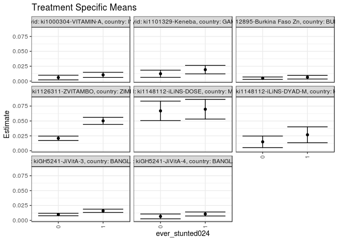

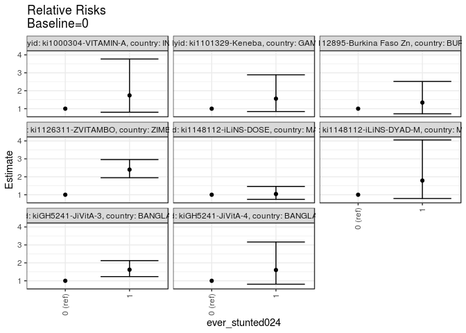

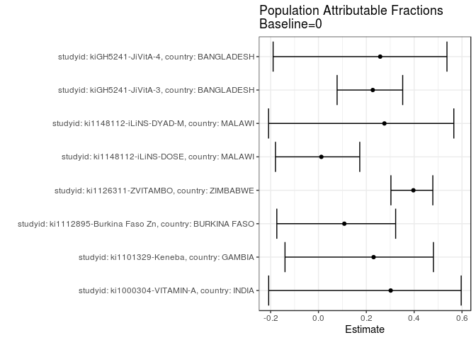

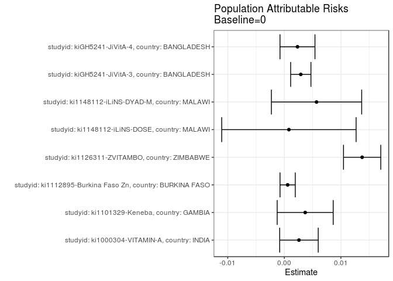

## Results Table

### Parameter: TSM

| studyid | country | intervention_level | baseline_level | estimate | ci_lower | ci_upper |
| --- | --- | --- | --- | --- | --- | --- |
| ki1000304-VITAMIN-A | INDIA | 0 | NA | 0.0059880 | 0.0020871 | 0.0098889 |
| ki1000304-VITAMIN-A | INDIA | 1 | NA | 0.0104216 | 0.0060889 | 0.0147543 |
| ki1101329-Keneba | GAMBIA | 0 | NA | 0.0123210 | 0.0062493 | 0.0183927 |
| ki1101329-Keneba | GAMBIA | 1 | NA | 0.0191957 | 0.0120791 | 0.0263123 |
| ki1112895-Burkina Faso Zn | BURKINA FASO | 0 | NA | 0.0048564 | 0.0028325 | 0.0068804 |
| ki1112895-Burkina Faso Zn | BURKINA FASO | 1 | NA | 0.0065102 | 0.0034320 | 0.0095884 |
| ki1126311-ZVITAMBO | ZIMBABWE | 0 | NA | 0.0209183 | 0.0172859 | 0.0245507 |
| ki1126311-ZVITAMBO | ZIMBABWE | 1 | NA | 0.0502093 | 0.0442973 | 0.0561212 |
| ki1148112-iLiNS-DOSE | MALAWI | 0 | NA | 0.0669553 | 0.0505915 | 0.0833192 |
| ki1148112-iLiNS-DOSE | MALAWI | 1 | NA | 0.0696802 | 0.0531695 | 0.0861908 |
| ki1148112-iLiNS-DYAD-M | MALAWI | 0 | NA | 0.0149750 | 0.0052609 | 0.0246892 |
| ki1148112-iLiNS-DYAD-M | MALAWI | 1 | NA | 0.0267857 | 0.0134075 | 0.0401639 |
| kiGH5241-JiVitA-3 | BANGLADESH | 0 | NA | 0.0099195 | 0.0078168 | 0.0120222 |
| kiGH5241-JiVitA-3 | BANGLADESH | 1 | NA | 0.0160552 | 0.0132471 | 0.0188634 |
| kiGH5241-JiVitA-4 | BANGLADESH | 0 | NA | 0.0066934 | 0.0026905 | 0.0106964 |
| kiGH5241-JiVitA-4 | BANGLADESH | 1 | NA | 0.0107233 | 0.0073531 | 0.0140935 |

### Parameter: E(Y)

| studyid | country | intervention_level | baseline_level | estimate | ci_lower | ci_upper |
| --- | --- | --- | --- | --- | --- | --- |
| ki1000304-VITAMIN-A | INDIA | NA | NA | 0.0085778 | 0.0055708 | 0.0115847 |
| ki1101329-Keneba | GAMBIA | NA | NA | 0.0160116 | 0.0113178 | 0.0207055 |
| ki1112895-Burkina Faso Zn | BURKINA FASO | NA | NA | 0.0054454 | 0.0037409 | 0.0071499 |
| ki1126311-ZVITAMBO | ZIMBABWE | NA | NA | 0.0346771 | 0.0313629 | 0.0379914 |
| ki1148112-iLiNS-DOSE | MALAWI | NA | NA | 0.0677695 | 0.0563864 | 0.0791525 |
| ki1148112-iLiNS-DYAD-M | MALAWI | NA | NA | 0.0206718 | 0.0124839 | 0.0288597 |
| kiGH5241-JiVitA-3 | BANGLADESH | NA | NA | 0.0128333 | 0.0112834 | 0.0143832 |
| kiGH5241-JiVitA-4 | BANGLADESH | NA | NA | 0.0090206 | 0.0064715 | 0.0115698 |

### Parameter: RR

| studyid | country | intervention_level | baseline_level | estimate | ci_lower | ci_upper |
| --- | --- | --- | --- | --- | --- | --- |
| ki1000304-VITAMIN-A | INDIA | 0 | 0 | 1.000000 | 1.0000000 | 1.000000 |
| ki1000304-VITAMIN-A | INDIA | 1 | 0 | 1.740407 | 0.8035728 | 3.769437 |
| ki1101329-Keneba | GAMBIA | 0 | 0 | 1.000000 | 1.0000000 | 1.000000 |
| ki1101329-Keneba | GAMBIA | 1 | 0 | 1.557961 | 0.8407617 | 2.886957 |
| ki1112895-Burkina Faso Zn | BURKINA FASO | 0 | 0 | 1.000000 | 1.0000000 | 1.000000 |
| ki1112895-Burkina Faso Zn | BURKINA FASO | 1 | 0 | 1.340529 | 0.7137279 | 2.517791 |
| ki1126311-ZVITAMBO | ZIMBABWE | 0 | 0 | 1.000000 | 1.0000000 | 1.000000 |
| ki1126311-ZVITAMBO | ZIMBABWE | 1 | 0 | 2.400256 | 1.9460992 | 2.960399 |
| ki1148112-iLiNS-DOSE | MALAWI | 0 | 0 | 1.000000 | 1.0000000 | 1.000000 |
| ki1148112-iLiNS-DOSE | MALAWI | 1 | 0 | 1.040696 | 0.7404161 | 1.462757 |
| ki1148112-iLiNS-DYAD-M | MALAWI | 0 | 0 | 1.000000 | 1.0000000 | 1.000000 |
| ki1148112-iLiNS-DYAD-M | MALAWI | 1 | 0 | 1.788690 | 0.7888293 | 4.055901 |
| kiGH5241-JiVitA-3 | BANGLADESH | 0 | 0 | 1.000000 | 1.0000000 | 1.000000 |
| kiGH5241-JiVitA-3 | BANGLADESH | 1 | 0 | 1.618555 | 1.2331955 | 2.124335 |
| kiGH5241-JiVitA-4 | BANGLADESH | 0 | 0 | 1.000000 | 1.0000000 | 1.000000 |
| kiGH5241-JiVitA-4 | BANGLADESH | 1 | 0 | 1.602070 | 0.8115092 | 3.162784 |

### Parameter: PAR

| studyid | country | intervention_level | baseline_level | estimate | ci_lower | ci_upper |
| --- | --- | --- | --- | --- | --- | --- |
| ki1000304-VITAMIN-A | INDIA | 0 | NA | 0.0025897 | -0.0008164 | 0.0059959 |
| ki1101329-Keneba | GAMBIA | 0 | NA | 0.0036906 | -0.0012597 | 0.0086409 |
| ki1112895-Burkina Faso Zn | BURKINA FASO | 0 | NA | 0.0005890 | -0.0007594 | 0.0019373 |
| ki1126311-ZVITAMBO | ZIMBABWE | 0 | NA | 0.0137588 | 0.0104635 | 0.0170542 |
| ki1148112-iLiNS-DOSE | MALAWI | 0 | NA | 0.0008141 | -0.0110648 | 0.0126930 |
| ki1148112-iLiNS-DYAD-M | MALAWI | 0 | NA | 0.0056968 | -0.0022850 | 0.0136786 |
| kiGH5241-JiVitA-3 | BANGLADESH | 0 | NA | 0.0029138 | 0.0011223 | 0.0047054 |
| kiGH5241-JiVitA-4 | BANGLADESH | 0 | NA | 0.0023272 | -0.0007641 | 0.0054185 |

### Parameter: PAF

| studyid | country | intervention_level | baseline_level | estimate | ci_lower | ci_upper |
| --- | --- | --- | --- | --- | --- | --- |
| ki1000304-VITAMIN-A | INDIA | 0 | NA | 0.3019122 | -0.2081567 | 0.5966363 |
| ki1101329-Keneba | GAMBIA | 0 | NA | 0.2304958 | -0.1399580 | 0.4805627 |
| ki1112895-Burkina Faso Zn | BURKINA FASO | 0 | NA | 0.1081571 | -0.1741959 | 0.3226141 |
| ki1126311-ZVITAMBO | ZIMBABWE | 0 | NA | 0.3967697 | 0.3028806 | 0.4780137 |
| ki1148112-iLiNS-DOSE | MALAWI | 0 | NA | 0.0120133 | -0.1797693 | 0.1726199 |
| ki1148112-iLiNS-DYAD-M | MALAWI | 0 | NA | 0.2755824 | -0.2087142 | 0.5658354 |
| kiGH5241-JiVitA-3 | BANGLADESH | 0 | NA | 0.2270516 | 0.0779022 | 0.3520760 |
| kiGH5241-JiVitA-4 | BANGLADESH | 0 | NA | 0.2579878 | -0.1895753 | 0.5371608 |